# Health Forecasting

## Introduction

In this markdown, we will present some ideas to propose forecasting time series data in R. To illustrate the methods we will be using, we will focus on the use of COVID tracking data, available on [covidtracking.com](https://covidtracking.com/data). This dataset presents various numbers related to COVID, such as the number of death, hospitalizations or tests, for each state of the United States. From this data, our objective will be to propose and evaluate methods, that would be able to forecast the evolution of the number of currently hospitalized people, in a given state.

## Importing libraries

```r
library(tidyverse)
library(finalfit)
library(broom)
library(tsibble)
library(fable)
library(feasts)
```

## Loading the dataset

The first step we need to follow is the loading of the data. To do so, we will extract it from a csv file, and put it into the variable `data`. Once this is done, we can use the missing_glimpse function, from the `finalfit` library, that allows us to visualize the different columns composing our dataset, their type (continuous or categorical) and the number of missing values for each column. Here, to illustrate our results, we will focus on data concerning the state of Colorado. For this reason, we will create another variable `data_co` containing the data that interests us.

```r
data <- read_csv("data.csv")
missing_glimpse(data)
```

```
##                                                             label var_type
## date                                                         date   <date>
## state                                                       state    <chr>
## death                                                       death    <dbl>
## deathConfirmed                                     deathConfirmed    <dbl>
## deathIncrease                                       deathIncrease    <dbl>
## deathProbable                                       deathProbable    <dbl>
## hospitalized                                         hospitalized    <dbl>
## hospitalizedCumulative                     hospitalizedCumulative    <dbl>
## hospitalizedCurrently                       hospitalizedCurrently    <dbl>
## hospitalizedIncrease                         hospitalizedIncrease    <dbl>
## inIcuCumulative                                   inIcuCumulative    <dbl>
## inIcuCurrently                                     inIcuCurrently    <dbl>
## negative                                                 negative    <dbl>
## negativeIncrease                                 negativeIncrease    <dbl>
## negativeTestsAntibody                       negativeTestsAntibody    <dbl>
## negativeTestsPeopleAntibody           negativeTestsPeopleAntibody    <dbl>
## negativeTestsViral                             negativeTestsViral    <dbl>
## onVentilatorCumulative                     onVentilatorCumulative    <dbl>
## onVentilatorCurrently                       onVentilatorCurrently    <dbl>
## positive                                                 positive    <dbl>
## positiveCasesViral                             positiveCasesViral    <dbl>
## positiveIncrease                                 positiveIncrease    <dbl>
## positiveScore                                       positiveScore    <dbl>
## positiveTestsAntibody                       positiveTestsAntibody    <dbl>
## positiveTestsAntigen                         positiveTestsAntigen    <dbl>
## positiveTestsPeopleAntibody           positiveTestsPeopleAntibody    <dbl>
## positiveTestsPeopleAntigen             positiveTestsPeopleAntigen    <dbl>
## positiveTestsViral                             positiveTestsViral    <dbl>
## recovered                                               recovered    <dbl>
## totalTestEncountersViral                 totalTestEncountersViral    <dbl>
## totalTestEncountersViralIncrease totalTestEncountersViralIncrease    <dbl>
## totalTestResults                                 totalTestResults    <dbl>
## totalTestResultsIncrease                 totalTestResultsIncrease    <dbl>
## totalTestsAntibody                             totalTestsAntibody    <dbl>
## totalTestsAntigen                               totalTestsAntigen    <dbl>
## totalTestsPeopleAntibody                 totalTestsPeopleAntibody    <dbl>
## totalTestsPeopleAntigen                   totalTestsPeopleAntigen    <dbl>
## totalTestsPeopleViral                       totalTestsPeopleViral    <dbl>
## totalTestsPeopleViralIncrease       totalTestsPeopleViralIncrease    <dbl>
```

[output cut: 29 more lines]

```
## positiveTestsPeopleAntigen         633     20147            97.0
## positiveTestsViral                8958     11822            56.9
## recovered                        12003      8777            42.2
## totalTestEncountersViral          5231     15549            74.8
## totalTestEncountersViralIncrease 20780         0             0.0
## totalTestResults                 20614       166             0.8
## totalTestResultsIncrease         20780         0             0.0
## totalTestsAntibody                4789     15991            77.0
## totalTestsAntigen                 3421     17359            83.5
## totalTestsPeopleAntibody          2200     18580            89.4
## totalTestsPeopleAntigen            999     19781            95.2
## totalTestsPeopleViral             9181     11599            55.8
## totalTestsPeopleViralIncrease    20780         0             0.0
## totalTestsViral                  14516      6264            30.1
## totalTestsViralIncrease          20780         0             0.0
```

```r
data_co <- as_tsibble(data %>% filter(state=="CO"), index = date)
```

Once the data is prepared, a first idea would be to plot it.

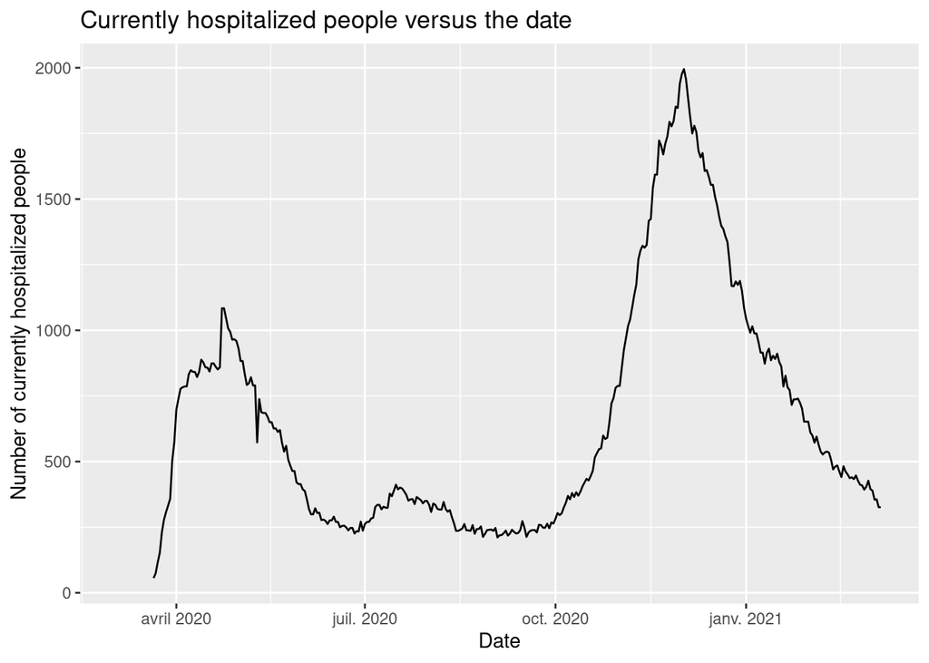

```r
data_co %>% ggplot(aes(x = date, y = hospitalizedCurrently))+
  geom_line()+
  ggtitle('Currently hospitalized people versus the date')+
  xlab('Date')+
  ylab('Number of currently hospitalized people')
```

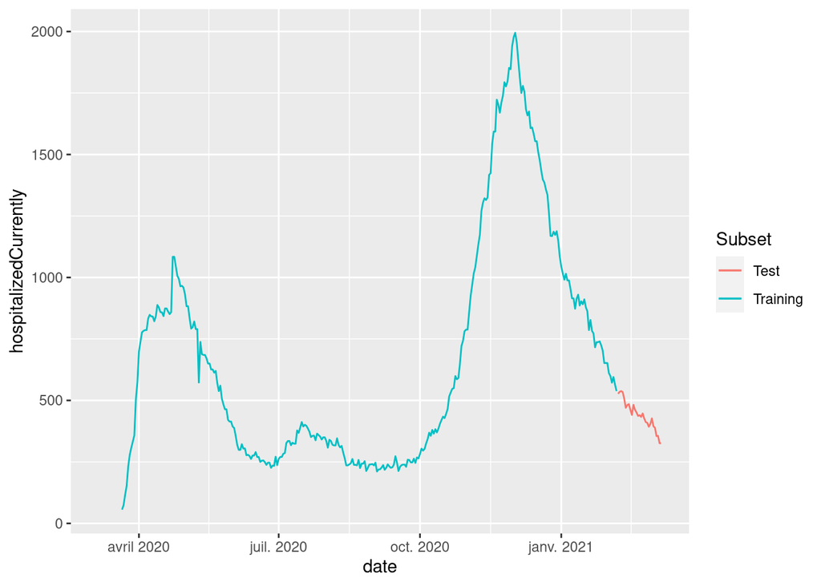

```r
train <- data_co %>%
  filter_index("2020-03-06" ~ "2021-02-06")

test <- data_co %>%
  filter_index("2021-02-07" ~ .)

ggplot()+
  geom_line(data = train, aes(x = date, y = hospitalizedCurrently, colour = 'red'))+
  geom_line(data = test, aes(x = date, y = hospitalizedCurrently, colour = 'darkblue'))+
    scale_color_discrete(name = "Subset", labels = c("Test", "Training"))
```

## Simple forecasting methods

In this document, we will study different forecasting methods, starting with simple ones. Forecasting can indeed be performed by analyzing the shape of a curve. To do so we can imagine several ideas:

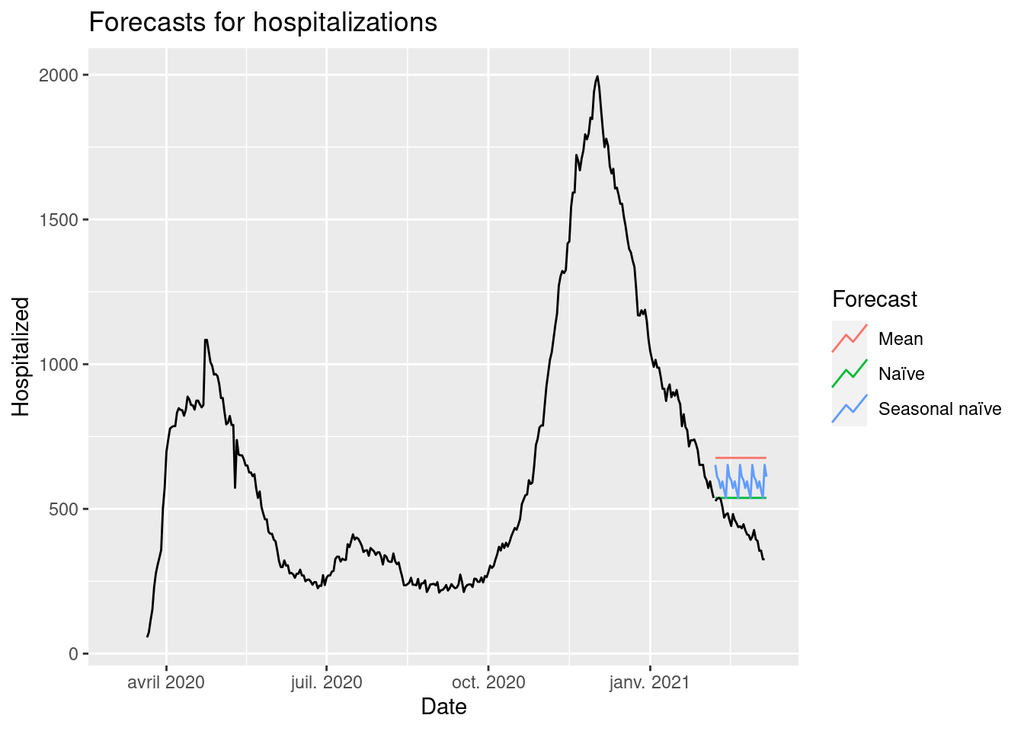

```r
train <- data_co %>%
  filter_index("2020-03-06" ~ "2021-02-06")

hospitalized_fit <- train %>%
  model(
    Mean = MEAN(hospitalizedCurrently),
    `Naïve` = NAIVE(hospitalizedCurrently),
    `Seasonal naïve` = SNAIVE(hospitalizedCurrently)
  )

# Generate forecasts for 20 days
hospitalized_fc <- hospitalized_fit %>% forecast(h = 30)

hospitalized_fc %>%
  autoplot(train, level = NULL) +
  autolayer(
    filter_index(data_co, "2021-02-07" ~ .),
    .vars = hospitalizedCurrently,
    colour = "black"
  ) +
  labs(
    x = "Date",
    y = "Hospitalized",
    title = "Forecasts for hospitalizations"
  ) +
  guides(colour = guide_legend(title = "Forecast"))
```

As we could imagine, these simple models don’t seem to fit properly our initial distribution. According to the precision we need on our prediction, such models can sometimes give us a good sense of scale of what we should expect. However, in most of the cases, they will appear to be too simple to describe our data and will need to be improve in order to get a more satisfactory forecast. To improve our models, we can first visualize the residuals for each model, which simply corresponds to the difference between the observed values and the predicted one.

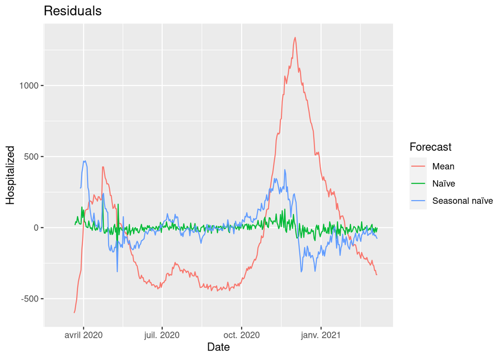

```r
aug <- data_co %>%
  model(
    Mean = MEAN(hospitalizedCurrently),
    `Naïve` = NAIVE(hospitalizedCurrently),
    `Seasonal naïve` = SNAIVE(hospitalizedCurrently)
  ) %>%
  augment()

autoplot(aug, .innov) +
  labs(x = "Date",
       y = "Hospitalized",
       title = "Residuals")+
  guides(colour = guide_legend(title = "Forecast"))
```

In our example, it seems that the naive method presents the best results, as the residuals are closer to zero than for the other methods. However, the visual information is not sufficient to evaluate the quality of our forecasting. For the following, we will still focus on the naive method, and try to propose some improvements.

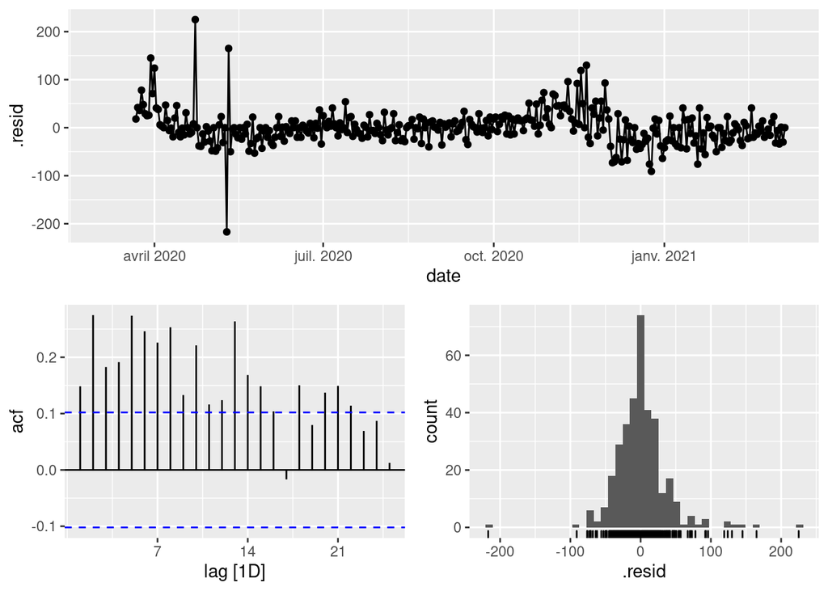

```r
data_co %>%
  model(NAIVE(hospitalizedCurrently)) %>%
  gg_tsresiduals()
```

If we assume that the distribution of the possible future values follows a normal distribution, we can now propose confidence intervals on our predictions. Here, we propose to visualize 80% and 95% confidence intervals and compare it with your observed data. We can assume that our confidence intervals may be inaccurate, as the normal distribution assumption may not be very appropriate, regarding the histogram of the residuals.

```r
train %>%
  model(NAIVE(hospitalizedCurrently)) %>%
  forecast(h = 30) %>%
  hilo()
```

```
## # A tsibble: 30 x 6 [1D]
## # Key:       .model [1]
##    .model             date       hospitalizedCurre… .mean                  `80%`
##    <chr>              <date>                 <dist> <dbl>                 <hilo>
##  1 NAIVE(hospitalize… 2021-02-07       N(538, 1442)   538 [489.3358, 586.6642]80
##  2 NAIVE(hospitalize… 2021-02-08       N(538, 2884)   538 [469.1785, 606.8215]80
##  3 NAIVE(hospitalize… 2021-02-09       N(538, 4326)   538 [453.7112, 622.2888]80
##  4 NAIVE(hospitalize… 2021-02-10       N(538, 5768)   538 [440.6717, 635.3283]80
##  5 NAIVE(hospitalize… 2021-02-11       N(538, 7210)   538 [429.1836, 646.8164]80
##  6 NAIVE(hospitalize… 2021-02-12       N(538, 8652)   538 [418.7976, 657.2024]80
##  7 NAIVE(hospitalize… 2021-02-13      N(538, 10094)   538 [409.2467, 666.7533]80
##  8 NAIVE(hospitalize… 2021-02-14      N(538, 11536)   538 [400.3569, 675.6431]80
##  9 NAIVE(hospitalize… 2021-02-15      N(538, 12977)   538 [392.0075, 683.9925]80
## 10 NAIVE(hospitalize… 2021-02-16      N(538, 14419)   538 [384.1104, 691.8896]80
## # … with 20 more rows, and 1 more variable: 95% <hilo>
```

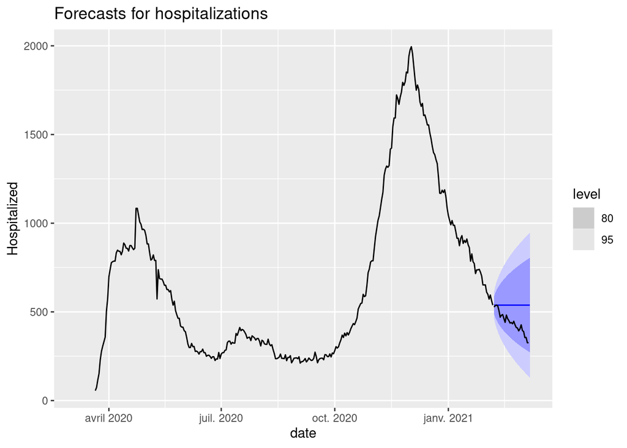

```r
train %>%
  model(NAIVE(hospitalizedCurrently)) %>%
  forecast(h = 30) %>%
  autoplot(train) +
  autolayer(
    filter_index(data_co, "2021-02-07" ~ .),
    .vars = hospitalizedCurrently,
    colour = "black"
  ) +
  labs(title="Forecasts for hospitalizations", y="Hospitalized" )
```

In our case, naive method allows us to produce quite reliable confidence intervals, as all observed values are in the 80% interval. However, proposed intervals are quite large, especially when we want to forecast values in a relatively far future. Our objective will now to explore other methods, that can eventually produce smallest confidence intervals.